# Regression

## Learning Objectives

By the end of this practical lab you will be able to:

- Perform Simple and Multiple Regression using OLS
- Explore OLS residuals
- Caclulate a Contiguity Spatial Matrix
- Perform some basic Spatial Regression

## Regression Basics

Along with descriptive statistics and plots, obtaining correlation measures between variables is often very helpful in understanding the underlying patterns of our observations, selecting variables, and generally aid in the “exploratory data analysis” stage of our modelling.

While correlation gives us an idea on the level of association between two variables, it cannot be used to predict values, especially if more than one variable is involved.

For instance, suppose we are exploring insurance penetration in Phoenix, Arizona. Regression will help us identify how much insurance levels will change when i.e. employment rates also change. Simple linear regression is typically a function of the form:
$$y = \alpha + \beta x + \varepsilon$$
where $y$ is the variable we are trying to predict, called *dependent* variable and $x$ is the variable that is used to make the prediction, called *independent* variable. In a regression model, a dependent variable $y$ would thus be equal to $\alpha$, which is a number called *intercept*, plus $\beta$ times the independent variable $x$, which is called *coefficient*, plus the error term $\varepsilon$. The latter is essential; within socio-economic phenomena it is extremely rare for one variable to completely predict another one without error, so value $\varepsilon$ describes the error of our model.

Suppose in this case our dependant variable is insurance ratio and our independent (or predictor) variable is unemployment rate. Let’s start by loading all necessary libraries and data into R.

```r
# Load libraries
library(RColorBrewer)
library(rgdal)
library(sp)
library(spdep)
library(tmap)
```

```r
# Load data
insurance.data <- read.csv("data/phoenix_insurance_data.csv")

# Preview
head(insurance.data)
```

```
##     STATE COUNTY_CODE          COUNTY TRACT pop_tot insured uninsured   pct_unins pct_insur med_age age_undr25 age_25_64 age_65over pct_undr25 pct_25_64 pct_65over labor_frc employed unemployed     pct_empl  pct_unemp married   pct_mar white pct_white hisp    pct_hisp med_income
## 1 Arizona          13 Maricopa County 10101    4957    4718       239 0.048214646 0.9517854    54.5        852      2361       1744 0.17187815 0.4762961  0.3518257      1985     1813        172 0.9133501259 0.08664987    3458 0.7807632  4836 0.9755901   29 0.005850313     106818
## 2 Arizona          13 Maricopa County 10102    4033    3996        37 0.009174312 0.9908257    64.1        176      2030       1827 0.04363997 0.5033474  0.4530126      1666     1602         64 0.9615846339 0.03841537    3341 0.8566667  3820 0.9471857   73 0.018100669     132822
## 3 Arizona          13 Maricopa County 30401    4037    3776       221 0.055291469 0.9447085    65.6        265      1694       2078 0.06564280 0.4196185  0.5147387      1520     1480         40 0.9736842105 0.02631579    2514 0.6466049  3791 0.9390637  179 0.044339856      97188
## 4 Arizona          13 Maricopa County 30402    3940    3670       270 0.068527919 0.9314721    55.9        778      2128       1034 0.19746193 0.5401015  0.2624365      1679     1513        166  0.901131626 0.09886837    2275 0.6479635  3642 0.9243655  137 0.034771574      76069
## 5 Arizona          13 Maricopa County 40502    5221    4293       888 0.171395484 0.8286045    52.1       1242      2376       1603 0.23788546 0.4550852  0.3070293      2209     2089        116 0.9456767768 0.05251245    2232 0.5077343  4384 0.8396859  753 0.144225244      32424
## 6 Arizona          13 Maricopa County 40506    5334    5102       232 0.043494563 0.9565054    72.9          0      1265       4069 0.00000000 0.2371579  0.7628421      1042      930        112 0.8925143954 0.10748560    3087 0.5787402  5300 0.9936258    0 0.000000000      38090
```

In this case we will use simple linear regression to model the relationship, i.e. only our predictor is used. Regression is usually preformed by fitting a line using the Ordinary Least Squares (OLS) method in order to estimate the unknown parameters of the regression line.

In this case, variable *pct_insur* shows the percentage of population with insurance and will be the dependent variable. For a simple regression, we will test the relationship between insurance penetration rates and unemployed population percentage (variable *pct_unemp*).

In R, a linear regression model can be fitted with the built-in `lm()` function (several libraries provide much more advanced models). This function accepts formulas which can be denoted by the `~` character. We can also easily visualise the actual the data points and the plot the regression line using `plot()` and `abline()` respectively.

```r
# Perform regression on insurance using unemployment as the independent variable
insurance.model <-  lm(pct_insur ~ pct_unemp, data = insurance.data, na.action=na.exclude)
summary(insurance.model)
```

```
##
## Call:
## lm(formula = pct_insur ~ pct_unemp, data = insurance.data, na.action = na.exclude)
##
## Residuals:
##      Min       1Q   Median       3Q      Max
## -0.35146 -0.04958  0.01564  0.06220  0.42004
##
## Coefficients:
##              Estimate Std. Error t value Pr(>|t|)
## (Intercept)  0.926301   0.005223  177.36   <2e-16 ***
## pct_unemp   -0.916234   0.052819  -17.35   <2e-16 ***
## ---
## Signif. codes:  0 '***' 0.001 '**' 0.01 '*' 0.05 '.' 0.1 ' ' 1
##
## Residual standard error: 0.08816 on 983 degrees of freedom
##   (6 observations deleted due to missingness)
## Multiple R-squared:  0.2344, Adjusted R-squared:  0.2336
## F-statistic: 300.9 on 1 and 983 DF,  p-value: < 2.2e-16
```

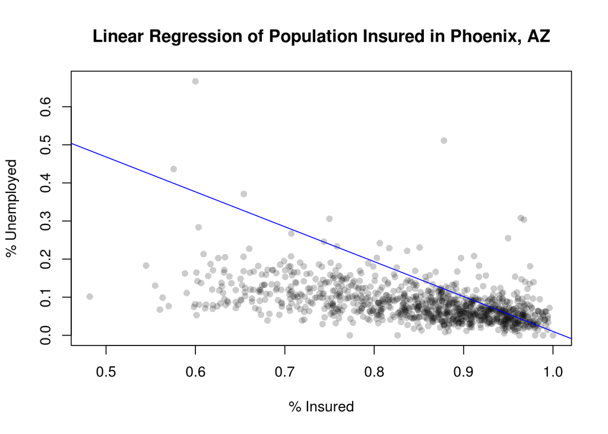

```r
plot(insurance.data$pct_insur, insurance.data$pct_unemp,
     xlab = "% Insured",
     ylab = "% Unemployed",
     main = "Linear Regression of Population Insured in Phoenix, AZ",
     col = rgb(0, 0, 0, 0.2), pch = 16)
abline(insurance.model, col = "blue")
```

At first glance it seems that unemployment rate does not give us a great predition of insurance levels. The output on the console gives some information on the model parameters. Of particular importance is the significance level of the independent variable (in this case unemployment is significant at > 99.9% probability), and the *R-squared* or usually the *Adjusted R-squared* which is 0.2336. In general, higher values of R-squared suggest that the model has a greater explanatory performance than lower values. In this case an R-squared of 0.2336 suggests that the model explains ~23% of the variation of Insurance levels.

## Multiple Regression

There is still ~77% of variation that our model does not explain. Typically, we try to account for this variation using additional predictor variables. This type of regression is called *Multiple Regression*.

```r
# Perform regression on insurance using multiple independent variables
insurance.model <-  lm(pct_insur ~ pct_unemp + pct_mar + pct_65over + pct_white + pct_hisp,
                       data = insurance.data,
                       na.action=na.exclude)
summary(insurance.model)
```

```
##
## Call:
## lm(formula = pct_insur ~ pct_unemp + pct_mar + pct_65over + pct_white +
##     pct_hisp, data = insurance.data, na.action = na.exclude)
##
## Residuals:
##      Min       1Q   Median       3Q      Max
## -0.36098 -0.02759  0.00421  0.03271  0.19914
##
## Coefficients:
##             Estimate Std. Error t value Pr(>|t|)
## (Intercept)  0.82627    0.01818  45.456  < 2e-16 ***
## pct_unemp   -0.29705    0.03793  -7.831 1.25e-14 ***
## pct_mar      0.21831    0.01594  13.693  < 2e-16 ***
## pct_65over   0.02385    0.01361   1.752   0.0801 .
## pct_white    0.01144    0.02041   0.561   0.5752
## pct_hisp    -0.23333    0.01928 -12.103  < 2e-16 ***
## ---
## Signif. codes:  0 '***' 0.001 '**' 0.01 '*' 0.05 '.' 0.1 ' ' 1
##
## Residual standard error: 0.05264 on 979 degrees of freedom
##   (6 observations deleted due to missingness)
## Multiple R-squared:  0.7282, Adjusted R-squared:  0.7268
## F-statistic: 524.6 on 5 and 979 DF,  p-value: < 2.2e-16
```

This model appears to explain the variability of insurance levels better, since the adjusted R-squared is 0.7268. However, some of the variables are not so significant, as indicated by each p-value. The p-value for each independent variable tests the null hypothesis that this variable has no correlation with the regression’s dependent variable. These variables are thus not good “predictors” of the dependant variable.

In this case, variable *pct_white* has very low significance (p = 0.5752) while *pct_65over* is marginally significant (p = 0.0801), which suggest that their correlation is not very significant. In most fields, the desired significance should be > 95%. As such we will exclude these two variables and re-run our regression. In this instance we will add information on median income, *med_income*, as well.

```r
# Perform regression on insurance using multiple predictor variables
insurance.model <-  lm(pct_insur ~ pct_unemp + pct_mar + pct_hisp + med_income,
                       data = insurance.data,
                       na.action=na.exclude)
summary(insurance.model)
```

```
##
## Call:
## lm(formula = pct_insur ~ pct_unemp + pct_mar + pct_hisp + med_income,
##     data = insurance.data, na.action = na.exclude)
##
## Residuals:
##      Min       1Q   Median       3Q      Max
## -0.36782 -0.02772  0.00335  0.03075  0.19183
##
## Coefficients:
##                   Estimate     Std. Error t value Pr(>|t|)
## (Intercept)  0.81728404904  0.01009249943  80.979  < 2e-16 ***
## pct_unemp   -0.24098353028  0.04132475977  -5.831 7.47e-09 ***
## pct_mar      0.18502107415  0.01729266337  10.699  < 2e-16 ***
## pct_hisp    -0.23093762328  0.00885710515 -26.074  < 2e-16 ***
## med_income   0.00000050886  0.00000009323   5.458 6.11e-08 ***
## ---
## Signif. codes:  0 '***' 0.001 '**' 0.01 '*' 0.05 '.' 0.1 ' ' 1
##
## Residual standard error: 0.05155 on 973 degrees of freedom
##   (13 observations deleted due to missingness)
## Multiple R-squared:  0.7381, Adjusted R-squared:  0.737
## F-statistic: 685.6 on 4 and 973 DF,  p-value: < 2.2e-16
```

Now all variables are significant at > 99% and our R-squared is at 0.737, which for most regression purposes is considered a fair model. A critical evaluation at this point however is to check the “residuals” of our model, which can be simply defined as the *error* term of the regression model descibed earlier.

## Residual Plots

Without going into too many mathematical details, in order for a regression model to be valid the error of a regression model should be random (stochastic). Homoscedasticity, i.e. that the error term does not change with the values of the independent variable, is one of the critical assumptions of regression models.

[Residual plots](http://docs.statwing.com/interpreting-residual-plots-to-improve-your-regression/) are a useful way of validating this concept. In OLS, residuals should not be systematically high or low for a portion of values but centered on zero throughout the range of $y$. We can return the predicted values and residuals of a linear regression model by using the `predict()` and `resid()` functions.

```r
# Make a data frame with actual, predicted and residual values
insurance.valid.data <- data.frame(actual = insurance.data$pct_insur, predicted = predict(insurance.model), residual = resid(insurance.model))

head(insurance.valid.data)
```

```
##      actual predicted    residual
## 1 0.9517854 0.9938650 -0.04207960
## 2 0.9908257 1.0299358 -0.03911009
## 3 0.9447085 0.9697934 -0.02508483
## 4 0.9314721 0.9440238 -0.01255171
## 5 0.8286045 0.8817632 -0.05315872
## 6 0.9565054 0.9178434  0.03866201
```

We can now plot the predicted values and residual values and look for any “suspicious” patterns.

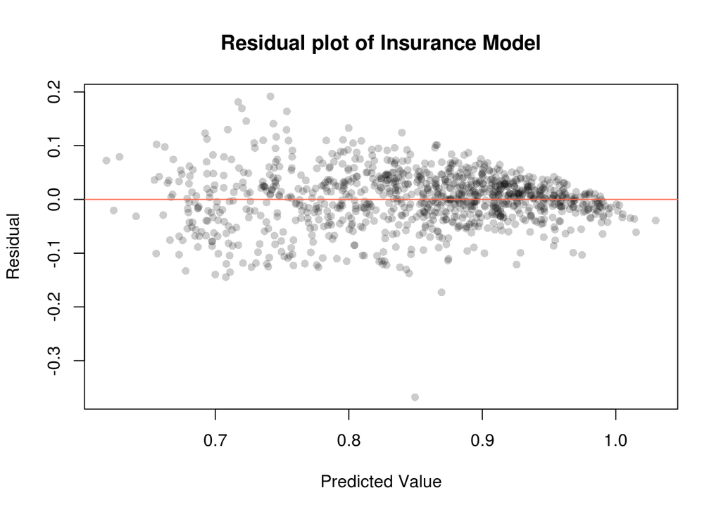

```r
# Plot the residuals
plot(insurance.valid.data$predicted, insurance.valid.data$residual,
     xlab = "Predicted Value",
     ylab = "Residual",
     main = "Residual plot of Insurance Model",
     col = rgb(0, 0, 0, 0.2), pch = 16)

abline(0,0, col = "tomato") # Zero baseline
```

In the residual plot residuals are much more spread out when there are low insurance levels than when there are high. In essence, our models perfrom better when insurance levels are high, but we are still missing information when insurance levels are low.

There are many ways such issues can be remedied; when working with geographical data in particular, it is very common that model performance can be affected because values have some degree of spatial association that our model has not taken into account. In this case, plotting a map of the residuals values and looking for meaningful spatial patterns will hint that another type of regression must be applied, called *spatial regression*.

## Spatial Regression Models

While regression can give us an easy model in order to predict values of the independent variable, it does not take into account its spatial patterns, which is very important within geographical analyses. In this example, it could be suggested that not all areas exhibit the same degree of association between insurance levels and demographics.

We can check these spatial patterns by looking at the *residuals* from the OLS, and plotting them over a map of the city. For instance, areas with generally high residuals suggest that our regression model does not perform well locally, meaning that spatial autocorrelation exists and should be taken into account when calculating model coefficients.

In order to perform spatial regression, the topological relationships of our entities (e.g. points, polygons etc) are needed; usually a shapefile with the data attached in enough to calculate the spatial weight and spatial lag matrix.

We can load shapefile data into R using the `readOGR()` function. The resulting object has many sub-classes that we can easily retrieve using the `@` character. For instance, we can retrieve the data subclass of an shapefile object with `shapefile@data`.

```r
# Read Shapefile
# setwd("c:/Users/dblalex/Desktop/chapter 6/Chapter 6 - Explaining the city/")
insurance.shp <- readOGR("data", "phoenix_insurance_data")
insurance.shp <- spTransform(insurance.shp, CRS("+proj=longlat +datum=WGS84"))
```

We can add the OLS residual values to the data object of the shapefile:

```r
# Append residuals to data
insurance.shp@data$ols_resid <-  resid(insurance.model)
```

And make a choropleth map of the residuals:

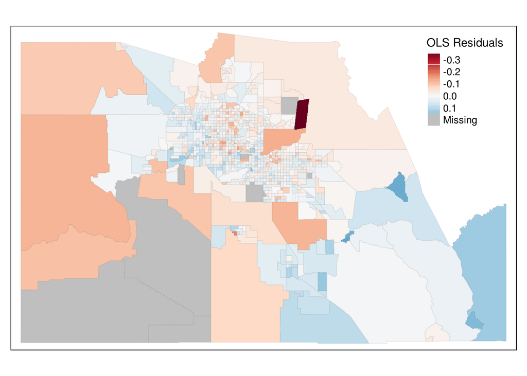

```r
# Make map of residuals
resid_map <- tm_shape(insurance.shp) +
             tm_polygons(style="cont", col = "ols_resid", palette="RdBu", n=7, title="OLS Residuals", border.alpha = 0.1) +
             tm_legend(text.size = .8)

resid_map
```

Since we have areas represented as polygons, we must first calculate a contiguity spatial matrix in order to capture such associations for the city’s neighborhoods.

```r
# Contiguity Spatial Matrix
sp.matrix <- poly2nb(insurance.shp, queen=TRUE)

# Calculating the weights matrix. "W" stands for row standardised values
sp.weights <- nb2listw(sp.matrix, style='W', zero.policy=TRUE)
```

A queen matrix means that associations are calculated diagonally as well (8 directions); in the case of polygons, a common point will suffice. We can visualise the associations by plotting a line between each neighboring polygon centroid, obtained with the `coordinates()` function.

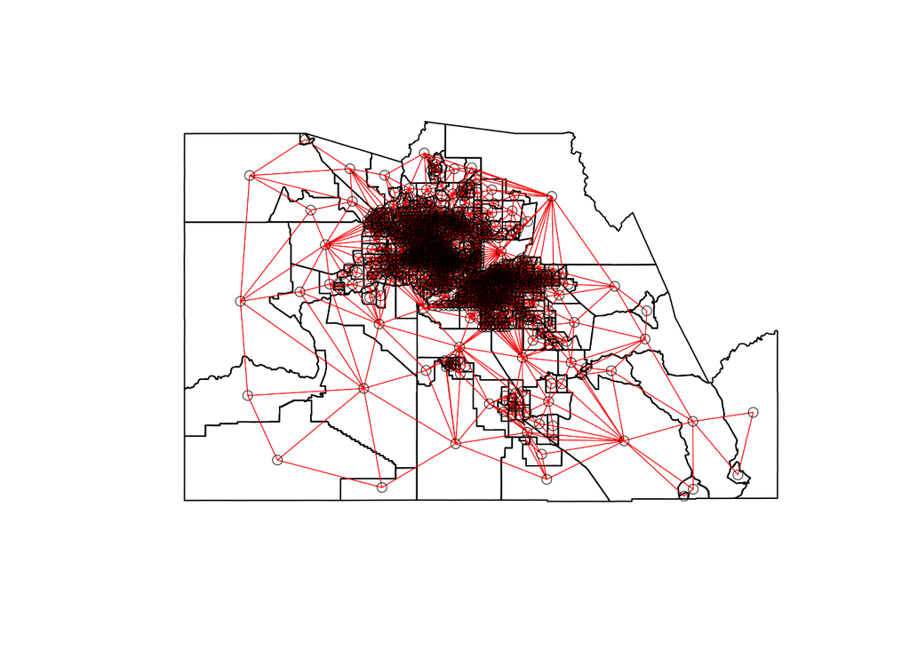

```r
# We can visualise spatial connections with the following map
plot(insurance.shp)
plot(sp.matrix, coordinates(insurance.shp),
     col='red', lwd=0.5,
     add=TRUE) # this argument plots the second map on top of the first one
```

Using the spatial matrix we can calculate the *I* statistic with the `moran.mc()` function. bBased on the p-value below, we can reject the null hypothesis that there is no spatial autocorrelation in our residuals, which suggests we will have to use a spatial approach to the regression.

```r
# Fix NAs to zero
resid_moran <- insurance.shp@data$ols_resid
resid_moran[is.na(resid_moran)] <- 0

# calculate I
moran.mc(resid_moran, listw = sp.weights, nsim = 999)
```

```
##
##  Monte-Carlo simulation of Moran I
##
## data:  resid_moran
## weights: sp.weights
## number of simulations + 1: 1000
##
## statistic = 0.21765, observed rank = 1000, p-value = 0.001
## alternative hypothesis: greater
```

The spatial regression model approach (often called *spatial lag* or *spatial error* models) is very similar to a traditional time-series regression, however correlations are adjusted to include spatial associations. The first one account for spatial dependencies as part of the dependent variable $y$ while the second as part of the error $\varepsilon$, depending on whether spatial autocorrelation can be regarded as substantive or nuisance respectively.

We can now run both a spatial lag and spatial error regression model and evaluate their results. The `lagsarlm()` and `errorsarlm()` functions from package `spdep` provide maximum likelihood estimation of spatial simultaneous autoregressive lag and error models respectively.

```r
# Run the two spatial regression models

# Spatial simultaneous autoregressive lag model
insurance.model.lag <- lagsarlm(pct_insur ~ pct_unemp + pct_mar + pct_65over + pct_hisp,
                                data=insurance.shp@data, sp.weights)
summary(insurance.model.lag, Nagelkerke = T)
```

```
##
## Call:lagsarlm(formula = pct_insur ~ pct_unemp + pct_mar + pct_65over +     pct_hisp, data = insurance.shp@data, listw = sp.weights)
##
## Residuals:
##        Min         1Q     Median         3Q        Max
## -0.3782225 -0.0269504  0.0043911  0.0307673  0.2119971
##
## Type: lag
## Coefficients: (asymptotic standard errors)
##              Estimate Std. Error  z value  Pr(>|z|)
## (Intercept)  0.575481   0.029924  19.2313 < 2.2e-16
## pct_unemp   -0.286594   0.034735  -8.2510  2.22e-16
## pct_mar      0.169605   0.015690  10.8096 < 2.2e-16
## pct_65over   0.036417   0.011891   3.0626  0.002194
## pct_hisp    -0.174078   0.011459 -15.1912 < 2.2e-16
##
## Rho: 0.30742, LR test value: 83.756, p-value: < 2.22e-16
## Asymptotic standard error: 0.033456
##     z-value: 9.1889, p-value: < 2.22e-16
## Wald statistic: 84.436, p-value: < 2.22e-16
##
## Log likelihood: 1547.235 for lag model
## ML residual variance (sigma squared): 0.0024921, (sigma: 0.049921)
## Nagelkerke pseudo-R-squared: 0.75027
## Number of observations: 985
## Number of parameters estimated: 7
## AIC: -3080.5, (AIC for lm: -2998.7)
## LM test for residual autocorrelation
## test value: 25.342, p-value: 0.00000048022
```

In general, spatial regresion models are difficult to [interpret](https://rpubs.com/corey_sparks/109650). Of particular importance here is the p-values of predictors, the simultaneous autoregressive lag coefficient *Rho* value, the LR and p-value of the spatial lag significance as well as the LM and AIC value (Akaike Information Criterion), which is a measure of the relative goodness of fit of a statistical model. This can be used to decide which of our models is best, as the preferred model is the one with the minimum AIC value. The *Rho* value tells us how strong the resemblance is, on average, between $y_i$ and it’s neighbors.

The results of the model indicate that probabilities for each of the predictor variables and the spatial lag are very significant, except variable _pct/*65over* which is marginally less significant (but still above 95%). The Nagelkerke pseudo-R-squared (0.75027) gives as the goodness of fit for logistic regression models, which has a similar interpretation to R-squared.

Information on the significance of the spatial lag is shown by the LR test and the z-test below. The *Likelihood Ratio test of spatial lag dependence* shows that results is significant. Therefore, we can conclude that the introduction of the spatial lag was an improvement to the model. The Lagrange Multiplier (LM) score test at the end of the output tests for the absence of spatial autocorrelation in the lag model residuals.

```r
# Spatial simultaneous autoregressive error model
insurance.model.error <- errorsarlm(pct_insur ~ pct_unemp + pct_mar + pct_65over + pct_hisp,
                                    data=insurance.shp@data, sp.weights)
summary(insurance.model.error, Nagelkerke = T)
```

```
##
## Call:errorsarlm(formula = pct_insur ~ pct_unemp + pct_mar + pct_65over +     pct_hisp, data = insurance.shp@data, listw = sp.weights)
##
## Residuals:
##        Min         1Q     Median         3Q        Max
## -0.3506524 -0.0258893  0.0052864  0.0297725  0.1972574
##
## Type: error
## Coefficients: (asymptotic standard errors)
##              Estimate Std. Error  z value  Pr(>|z|)
## (Intercept)  0.849518   0.011361  74.7744 < 2.2e-16
## pct_unemp   -0.325019   0.034928  -9.3053 < 2.2e-16
## pct_mar      0.187621   0.018074  10.3809 < 2.2e-16
## pct_65over   0.047154   0.014334   3.2895  0.001004
## pct_hisp    -0.238997   0.011096 -21.5389 < 2.2e-16
##
## Lambda: 0.4823, LR test value: 114.92, p-value: < 2.22e-16
## Asymptotic standard error: 0.0424
##     z-value: 11.375, p-value: < 2.22e-16
## Wald statistic: 129.39, p-value: < 2.22e-16
##
## Log likelihood: 1562.815 for error model
## ML residual variance (sigma squared): 0.0023547, (sigma: 0.048526)
## Nagelkerke pseudo-R-squared: 0.75805
## Number of observations: 985
## Number of parameters estimated: 7
## AIC: -3111.6, (AIC for lm: -2998.7)
```

```r
anova(insurance.model.lag, insurance.model.error)
```

```
##                       Model df     AIC logLik
## insurance.model.lag       1  7 -3080.5 1547.2
## insurance.model.error     2  7 -3111.6 1562.8
```

Further tests are needed in order to optimize the models, but the scope of this practical is to give you an introduction to spatial regression, particularly its concepts and basic interpretation. Spatial models can be quite complex, so there are a lot of materials available detailing specific aspects and variations of such models.

## Further resources / training

The book [“An Introduction to Generalized Linear Models”](https://www.crcpress.com/An-Introduction-to-Generalized-Linear-Models-Third-Edition/Dobson-Dobson-Barnett/p/book/9781584889502) by Dobson and Barnett provides a good examination of common regression models.

- Dobson, A.J. and Barnett, A., 2008. An introduction to generalized linear models. Third Edition. CRC press.

For a good overview on spatial models, see the book by Anselin, Florax and Rey (2004):

- Anselin, L., Florax, R. and Rey, S. (2004). Advances in Spatial Econometrics. Springer, Berlin.

Outside R, [GeoDA](https://spatial.uchicago.edu/geoda) also offers a variety of [tools](https://s4.ad.brown.edu/Resources/Tutorial/Modul2/GeoDa3FINAL.pdf) for performing spatial regression.